# GIT

Derek Van Berkel

2022-10-31

## Getting started with github

[figure not shown]

Next, you will create a new repository with the drop-down

[figure not shown]

Fill in the details of the repository. Give it name that makes sense. For the most part, I choose the public option, add a readme and .gitignore. You can also add a license if you like

[figure not shown]

[figure not shown]

I usally start a repository on github and initialize git on my computer for version control. This means that you will add file to git either through command line or the `Add file` button

[figure not shown]

### Steps for Hosting a HTML of your RMD as a Website on GitHubn (Bonus)

It is rather simple to make your html publicly available via github. Here is an example of one I made for a recent paper https://derekvanberkel.github.io/Planning-for-climate-migration-in-Great-Lake-Legacy-Cities/. Below are the step to make the knit html you make for this lab into a static website. Here is another website that give more detail https://blog.flycode.com/how-to-deploy-a-static-website-for-free-using-github-pages

- Create a GitHub account on github.com.
- Create a new repository in your GitHub application. The name is very important as this will become the url of the site. Note the folder that GitHub is saving the repository to. Make sure the “Push to GitHub?” box is checked. This will be the url of your website. Name it accordingly
- Move your html file that you knit into the folder that GitHub just created when you made the repository. IMPORTANT: Your homepage HTML file must be called “index.html”, and it must exist in the top-level directory.
- Enter a message in the text box called “commit summary”, something like “initial commit.” Then, click the commit button. +Now click the `Settings` button on the repository site. Navigate to the `Pages` tab and click it. Under branch click the `None` dropdown and choose main, and save it. +It might take some time (give it about 10 minutes), then check this page to see the url associated with the website. Your website should be live!

## Git hub and git hub (optional instruction)

Git is an open-source version control system that was developed by Linus Torvalds (the same person who developed Linux). What is version control? When we create some code, we are constantly changing it. Version control systems keep ‘versions’ of these change(you actually make the version description) in a central repository. This can help with collaboration, as everyone can download a new version of the software, make changes, and upload the newest revision. Every developer can see these new changes, download them, and contribute. Similarly, people who have nothing to do with the development of a project can still download the files and use them. Git is the preferred version control system of most developers, as it stores file changes more efficiently and ensures file integrity.

Github consists of *repositories (“repo”)*, which store all the files for a particular project. Each project has its own repo, and you can access it with a unique URL. You can create a new project based off of another project that already exists, which is called *“forking”*. This encourages the further development of programs and other projects. For example, if you find a project on GitHub that you find useful, you can fork the repo, make changes, and release the revised project as a new repo. If the original repository that you forked to create your new project gets updated, you can easily add those updates to your current fork. You can also create a *pull request*. The pull request allows the original author to see your work, and then choose whether or not to accept it into the official project. Each user on GitHub has their own profile that acts like a resume of sorts, showing your past work and contributions to other projects via pull requests. Project revisions can be discussed publicly, so a mass of experts can contribute knowledge and collaborate to advance a project forward. When multiple people collaborate on a project, it’s hard to keep track revisions — who changed what, when, and where those files are stored. GitHub takes care of this problem by keeping track of all the changes that have been pushed to the repository.

### Workflow and terminolgy

Credits: GutHub repository and Rahul Agrawal

#### Master

GitHub uses the term “master” or “main” for the primary version of a source code repository. Developers make copies of the “master” on their computers into which they add their own code, and then merge the changes back into the “master” repo.

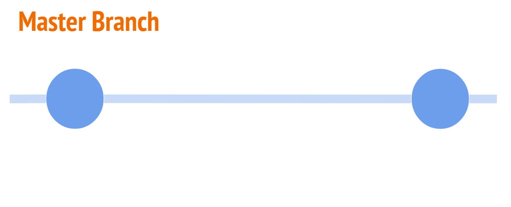

#### Branch

Branches allow you to develop features, fix bugs, or safely experiment with new ideas in a contained area of your repository.

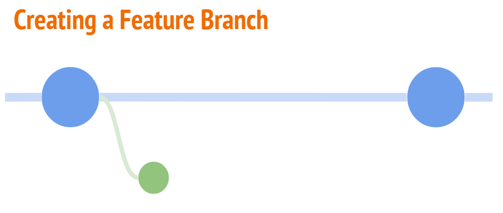

You always create a branch from an existing branch.Typically, you might create a new branch from the default branch of your repository. You can then work on this new branch in isolation from changes that other people are making to the repository. Best practice is to commit changes to the branch with messages that track your progress

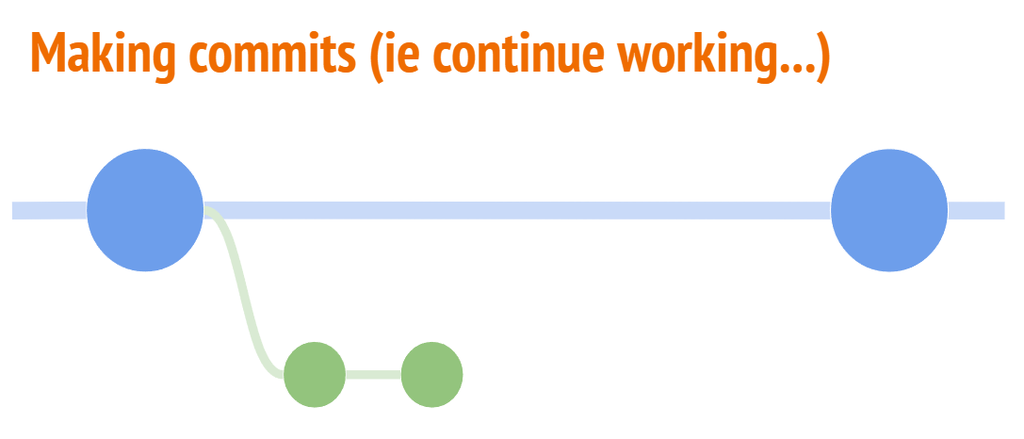

In practice, you can get help with a branch and work independently on it.

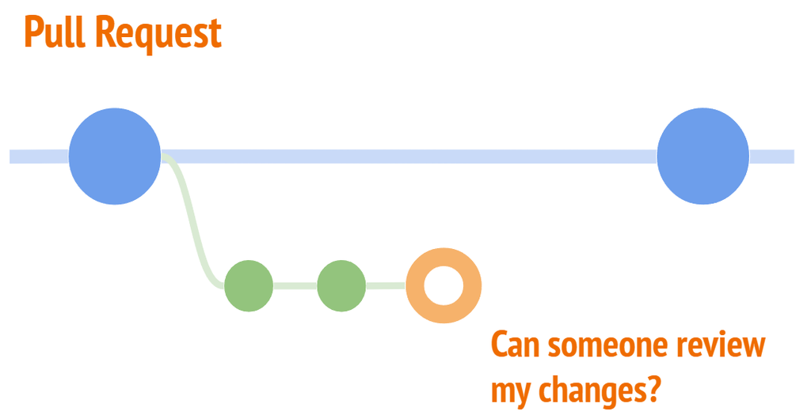

You document changes with new commit messages e.g. “testing new code for this map”

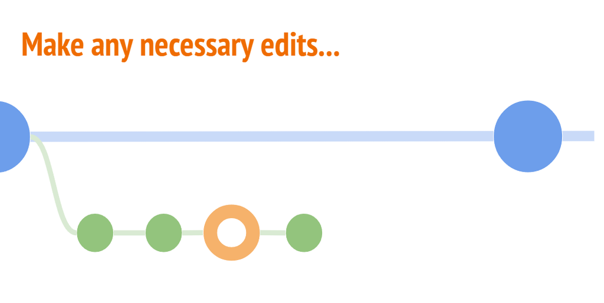

This allows you to go back to specific code stages, for example, if you made a change that didn’t work

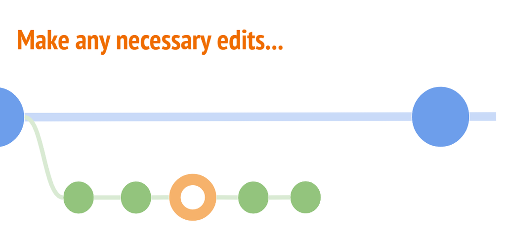

There is also the potential for automated testing in git.

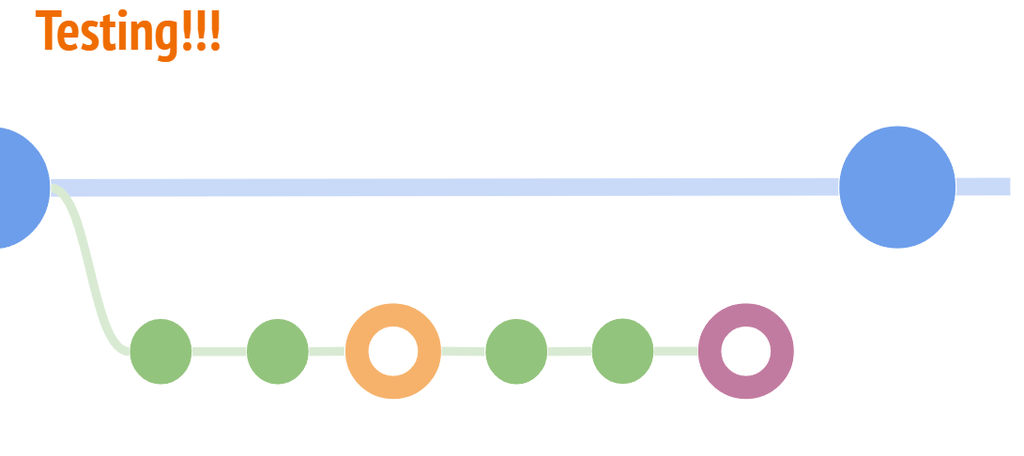

When you are happy with the changes you can merge back into the master

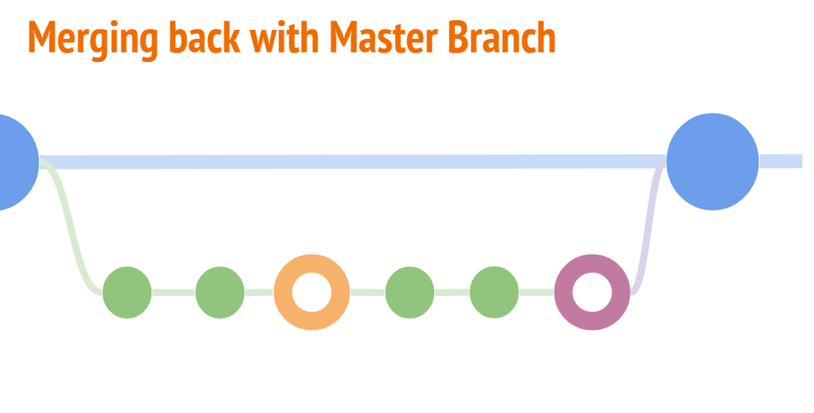

### Installation

Prior to using RStudio’s version control features you will need to ensure that you have Git installed on your system. You will need to install it using the appropriate method for your platform:

Windows & OS X: http://git-scm.com/downloads

## Command line git and git hub

This is some very basic instruction for using git with git hub. We will be using command line. (PC) or Terminal (Mac) to clone the repository to our computers. Both PCs and Macs should have the required software for this operation(but you might need to download git in some cases - Windows & OS X: http://git-scm.com/downloads). See additional instructions below. To start, we will navigate to the directory where we want to clone the repository. The code below allows you to change directories to your desired location:

PCs `cd C:\Data\tmp`

Macs `cd ~/Desktop/sass/css`

You can use `ls` (Mac) or `dir`(PC) to list the files and directories on the directory where you just navigated. This is helpful, as you will adding additional files to this directory from GitHub. Now we can use the git clone command to clone the repository into this directory. We are going to assume you created a Git repository as per above, and you want to copy it to your local machine. In this case, you will use th git clone command.

`git clone [url-to-existing-git-repo]`

It is good practice to check if git is “watching” this new folder using the `status` function. After type it, you should get `fatal: not a git repository (or any of the parent directories): .git`, as we have not told git to watch the folder.

`git status`

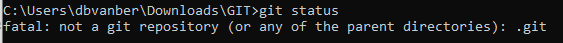

Because this is a new folder you will need to use the `git init` command, used to initialize a new, empty, Git repository.

`git init`

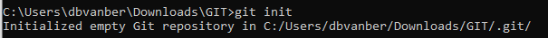

Now if you use the status function, `git status`, it should indicate that the branch is up to date. Note that I move into the folder using cd

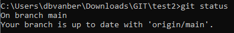

Changes to the file in the folder will now be tracked by git when we edit them. Remember that these will only be registered if you save them (e.g. modified code and). After saving your file(e.g. R scripts), you can use the status function to view registered changes e.g.,

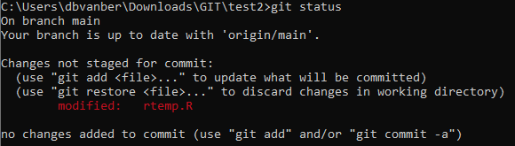

Note that it the message inidicates that the code has not be stagged for a commit. This basically forces you to tell git that these changes need to be added. You can add files that will be monitored by git using the `add` function. This can be done for individual files or all the files in folder. To do this you would need to move into the actual folder using the command line cd function.

`git add [file name] ### this add the specifed file`

`git add . ### the dot indicates that you want to add all files`

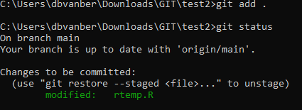

This indicates that we have staged the changes, and they are ready to be committed. The final commit needs a message that helps you know what stage of the coding you were on (i.e. breadcrumbs so you could return to that code if needed). The final commit function is used to give these messages.

`git commit -m "commit message" ## the -m flag indicates the message, which need to be in quotation marks`

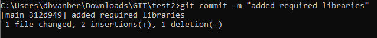

When you are happy with the changes you have made, you can push the changes up to github. Note that we are in the master branch, and this would result in merging to the original master. This can be done with this code

`git push origin main`

This brings up a prompt to give your github username and password. Enter these (for some it will work), for others you will need to get an api key. If you have never connected to your Github repository, you will be prompted to fill in your user id and password. This may work, but alternatively you might need to get your api key and fill in this information. Instructions can be found [here](https://docs.github.com/en/get-started/getting-started-with-git/about-remote-repositories#cloning-with-https-url). Use the API key as the password, if there are issues. I always have issues with this process, and hopefully you can get it to work

To work in branches, which isolates you from the master(main), you can create a new branch in command line. The follow creates a new branch, moves to the branch, and add the files you want to it.

`git branch [name of branch]`

`git checkout [name of branch]`

Use the typical add functions to add the files that you want to this branch. This branch can then be added to git

`git push origin [name_of_your_new_branch]`

If you started with using git on files locally, you will need to need to add the origin repository (one that you have created and want to push to). To get the repo, you can just go to github, and copy it again

`git remote add origin [the git repo] ### remember to add your repo url`